# Software tutorial 6

Reproducible research pipelines with R and Quarto

Valentin Klotzbücher

December 17, 2024

## Simulate Example

To illustrate different types of relationships and their statistical significance, we simulate a simple dataset where $y$ is linearly related to a vector of independent variables $\mathbf{X} = (1, x_1, x_2, x_3, x_4, x_5)$:

$$y = \mathbf{X}'\beta + \epsilon = 5 + 0.3\ x_1 + 0.07\ x_2 + 0.2\ x_5 + \epsilon$$

Let us assume that in the given context, an effect size of less than 0.15 (in any direction) is practically equivalent, i.e. not relevant.

We simulate the variables with varying levels of true effects and noise to illustrate different scenarios:

- Strong effects
- Trivial effects
- Imprecisely estimated effects
- Precisely estimated null effects

## Estimation results

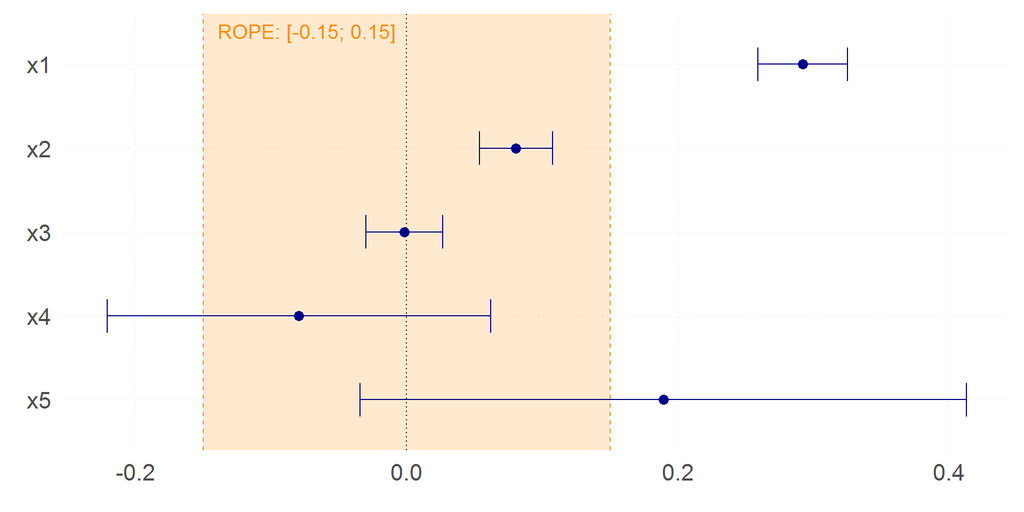

Estimated coefficients for $x_1$ and $x_2$:

- $\hat{\beta_1}=$ 0.29
- $\hat{\beta_2} =$ 0.08
- Close to the true values of 0.3 and 0.07
- Very small p-value, reject the null-hypotheses $\mathcal{H}^1_0:\ \beta_1=0$ and $\mathcal{H}^2_0:\ \beta_2=0$ for commonly used significance thresholds.

For $x_5$ on the other hand:

- Coefficient $\hat{\beta_5}=$ 0.189
- Close to true 0.2, but, due to low variation in $x_5$, estimated much less precisely
- If we were to use a significance-level of 5%, the p-value of 0.097would not allow for a rejection of the null hypothesis that $x_5$ has no effect on $y$, i.e. $\beta_5 = 0$.

For $x_3$ and $x_4$:

- We know that the true effect is zero,
- We would fail to reject the null of no effect
- Confidence interval around $\hat{\beta_4}$ substantially larger

## Interpretation: P-values and S-values

What does a p-value tell us exactly?

The probability to observe an effect at least as extreme as $|\hat{\beta}|$, if the null hypothesis is true, i.e. $\beta = 0$.

NOT the probability that the null hypothesis is true!

## S-values

Captures the “surprise” in an intuitive way:

- Assume that you want to test whether a coin is fair (50% probability to land on either side)
- Null hypothesis: coin is fair
- Keep tossing the coin to collect information whether it is fair
- How many times would you need to observe all heads to conclude that the coin is biased?<sup>1</sup>
[^1]: Check [this blog post](https://lesslikely.com/statistics/s-values/#s-value-calculator) for a more detailed explanation.

Translate p-values to s-values (bits of information) using the following formula:

$$s= -\log_2(p)$$

- For the effect of $x_5$, the evidence against the null hypothesis is only as strong as observing 3.37 heads in a row would speak against a coin being fair.
- For $x_1$, the s-value indicates that in a world where the true effects is zero, observing an effect at least as strong as $|\hat{\beta}_1|$ is about as likely as seeing all heads on 179.43 fair coin tosses.

## Equivalence testing

- When no significant effect is detected (e.g. the effect of $x_4$ and $x_5$), we cannot conclude that there is no effect - no evidence for an effect does not imply evidence of no effect.
- Equivalence testing can be used to determine whether an effect is small enough to be practically indistinguishable from zero within a predefined range, often called the Region of Practical Equivalence (ROPE).
- As Fitzgerald (2024) shows, equivalence testing is still very much underused in economics.
- P-value tests whether the coefficient is significantly different from zero.
- Non-significant result does not confirm that the coefficient is exactly zero
- Equivalence testing: actively test whether the coefficient lies entirely within the ROPE (e.g. here [−0.15,0.15]), i.e. too small to be practically meaningful.
- Confidence interval lies entirely within the ROPE: Effect is so small that it is practically equivalent to zero.

To obtain a p-value, one can perform a test for equivalence using the “two one-sided t-tests” (TOST) procedure, for a guide on implementing this in R see [this blog post](https://www.carlislerainey.com/blog/2023-08-18-equivalence-tests/).

So, assuming we see only the results and do not know the true relationships - what can we conclude about the effects of $\mathbf{X}$ on $y$?

- $x_1$: Meaningful, positive effect, significantly different from zero $\rightarrow\$ *Substantial*
- $x_2$: Significant but the CI lies completely inside the ROPE $\rightarrow\$ *Trivial*
- $x_3$: Precise null effect, CI completely inside the ROPE $\rightarrow\$ *Zero*
- $x_4$: Insignificant, s-value of 1.89 $\rightarrow\$ *Inconclusive*
- $x_5$: Significant on 10%-level, $\rightarrow\$ *Inconclusive (?)*

Another common mistake to avoid: “$x_1$ has a significant impact, while $x_5$ does not.” - the difference between significant and not significant is not itself statistically significant!

## Confidence intervals

Simulation exercise to illustrate how to interpret confidence intervals.<sup>1</sup>

Repeatedly draw samples from the “population”: Each confidence interval generated using a different random seed

How many of the confidence intervals contain the true value?

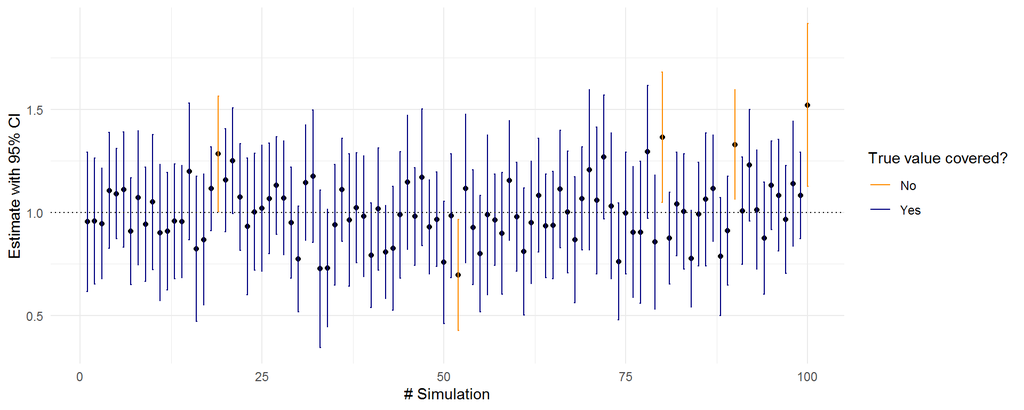

Figure 1: 100 Confidence Intervals for the Slope Coefficient

[^2]: Check [here](https://www.the100.ci/2024/12/05/why-you-are-not-allowed-to-say-that-your-95-confidence-interval-contains-the-true-parameter-with-a-probability-of-95/) for a more detailed, accessible explanation.

## Additional ressources

- Econometrics: Huntington-Klein (2021), Cunningham (2021)
- [Model to meaning](https://marginaleffects.com/)
- LinkedIn, YouTube: [Albert Rapp](https://albert-rapp.de/), [Sophie Lee](https://scubed.netlify.app/courses/)
- [Bluesky Starter pack](https://go.bsky.app/CWfcyfX) (currently many people moving from $\mathbb{X}$)

## More stuff that we should have covered but didn’t

- [Parameterized reports](https://posit.co/blog/parameterized-quarto/)
- [`renv`](https://youtu.be/Oen9xhEh8PY?si=O-fsf0VrrSJDK0Va)
- [Git](https://happygitwithr.com/)
- Databases and SQL, [DuckDB](https://grantmcdermott.com/duckdb-polars/)
- Connecting R LLMs through API
- Python and R with `reticulate`
- [`officeR`](https://davidgohel.github.io/officer/) to modify MS Office files (also check [`xlwings`](https://www.xlwings.org/features) with Python)
- Shiny Dashboards
- Panel data with [`fixest`](https://lrberge.github.io/fixest/)

Thank you!

Cunningham, Scott, “[Causal inference: The mixtape](https://mixtape.scunning.com/),” (Yale university press, 2021).

Fitzgerald, Jack, “[The need for equivalence testing in economics](https://hdl.handle.net/10419/296190),” 2024 (I4R Discussion Paper Series).

Huntington-Klein, Nick, “[The effect: An introduction to research design and causality](https://theeffectbook.net/),” (CRC Press, 2021).